# La Política de la Corrupción

Sesión 2: Leer un estudio con ojo crítico: cómo leer un artículo académico

Bogdan G. Popescu

bgpopescu@tec.mx

Tecnológico de Monterrey

## La idea central

Un artículo no es una colección de datos.

Es un **argumento**: evidencia y supuestos, ensamblados para que aceptes una conclusión.

Los datos se memorizan. Los argumentos se **evalúan**.

## Qué vas a poder hacer

Al terminar hoy, con cualquier artículo de cualquier ciencia social:

- Decir con precisión qué te están pidiendo creer
- Encontrar el supuesto que los autores nunca escribieron
- Decir qué otra cosa pudo haber producido su resultado
- Dar un veredicto calibrado en vez de un veredicto de gusto

## Los seis movimientos

```
%%{init: {"flowchart": {"useMaxWidth": true, "htmlLabels": false, "nodeSpacing": 10, "rankSpacing": 26, "padding": 12}, "themeVariables": {"fontSize": "12px", "edgeLabelBackground": "#f9fafb"}}}%%
flowchart LR
  M1["1<br/>AFIRMACIÓN"] --> M2["2<br/>ARGUMENTO"] --> M3["3<br/>MEDICIÓN"] --> M4["4<br/>COMPARAR"] --> M5["5<br/>RIVALES"] --> M6["6<br/>VEREDICTO"]
  style M1 fill:#1e293b,color:#f9fafb,stroke:#1e293b
  style M2 fill:#1e293b,color:#f9fafb,stroke:#1e293b
  style M3 fill:#4a7c6f,color:#f9fafb,stroke:#4a7c6f
  style M4 fill:#4a7c6f,color:#f9fafb,stroke:#4a7c6f
  style M5 fill:#b44527,color:#f9fafb,stroke:#b44527
  style M6 fill:#b7943a,color:#f9fafb,stroke:#b7943a
```

Los mismos seis, siempre, en este orden. Son un **procedimiento**, no una lista de vocabulario.

# Movimiento 1 — La afirmación

## Cuatro tipos de afirmación empírica

- **Descriptiva** — cómo es el mundo
- **Efecto causal** — X cambió a Y
- **Mecanismo** — *por qué* X cambió a Y
- **Generalización** — también se sostiene en otras partes

Afirmaciones distintas necesitan **evidencia distinta**. Los artículos se deslizan entre ellas.

## Un tema, cuatro afirmaciones

| **Descriptiva** | Las democracias rara vez pelean entre sí. |
| --- | --- |
| **Causal** | La democracia hace menos probable que un Estado pelee. |
| **Mecanismo** | …porque sus líderes temen el castigo electoral. |
| **General** | Cualquier democracia, en cualquier lugar, será pacífica. |

La evidencia para la primera no sostiene **ninguna** de las otras tres.

## El movimiento 1 en la práctica

Pregunta, antes que nada:

- ¿Cuál de las cuatro es la afirmación **principal** del artículo?
- ¿Cuál promete el **título**?
- ¿Cuál entrega la **sección de conclusiones**?

Cuando esas tres no coinciden, ya encontraste algo.

# Movimiento 2 — El argumento

## Forma estándar

Quita la prosa. Numera las premisas. Pon la conclusión al final.

> “Desde 1816, las democracias casi nunca han ido a la guerra entre sí. La democracia mantiene la paz.”

| P1. | Los pares de democracias rara vez pelearon entre sí. |
| --- | --- |
| C. | La democracia causa la paz entre ellas. |

Una premisa, y una conclusión enorme. Falta algo.

## La premisa que falta

| P1. | Los pares de democracias rara vez pelearon entre sí. |
| --- | --- |
| P2. *(no dicha)* | Su menor tasa de guerra no se debe a otros rasgos compartidos, como mayor riqueza, interdependencia económica o alianzas militares. |
| C. | La democracia causa la paz entre ellas. |

P2 no aparece **en ninguna parte** del texto — y sin ella el argumento se derrumba.

Una premisa no dicha que hace trabajo real es un **entimema**. Casi todo artículo tiene uno.

## Léelo con caridad

Antes de atacar, construye la versión **más fuerte** que el texto admita.

- Completa la premisa que el autor de verdad suscribiría
- No la más tonta, la que lo deja mal parado
- Si tu versión es fácil de demoler, la construiste mal

Criticar una reconstrucción débil no le dice nada al lector.

## Dónde se esconden las premisas

Vigila las palabras que **abren** o **cierran** una categoría:

- *como, por ejemplo, incluyendo* (*such as, for example, including*) — abren
- *estos, ninguno de estos, el/la* (*these, any of these, the*) — cierran
- *mera, suficiente, solo, no puede, descarta* (*mere, sufficient, only, cannot, rules out*) — fijan un límite

> “Controlamos por intereses compartidos **como** alianza, comercio y riqueza — y **ninguno de estos** explica la paz democrática.”

Un artículo que **abre** una categoría y la **cierra** una frase después dio por supuesto que la lista estaba completa.

Ese supuesto casi nunca se enuncia.

# Movimiento 3 — Medición

## ¿Qué se observó realmente?

El concepto del título rara vez es la cosa que está en la base de datos.

| Concepto afirmado | Cosa medida |
| --- | --- |
| democracia | un puntaje mayor a 6 en un índice de democracia |
| guerra | 1,000+ muertes en combate al año |
| intereses compartidos | un tratado de alianza registrado |
| líderes que temen al votante | …nada |

Pregunta: ¿la medida **captura** el concepto, o solo correlaciona con él?

## Dos niveles

```
%%{init: {"flowchart": {"useMaxWidth": true, "htmlLabels": false, "nodeSpacing": 22, "rankSpacing": 56, "padding": 18}, "themeVariables": {"fontSize": "13px", "edgeLabelBackground": "#f9fafb"}}}%%
flowchart LR
  G["MEDIDO<br/>pares de países,<br/>una fila por año"] -.->|"¿esto se sigue?"| I["AFIRMADO<br/>individuos:<br/>votantes, líderes"]
  style G fill:#4a7c6f,color:#f9fafb,stroke:#4a7c6f
  style I fill:#b44527,color:#f9fafb,stroke:#b44527
```

Movimiento 1, renglón tres: las democracias se mantienen en paz **porque sus líderes temen el castigo electoral**.

Lo que se midió: los pares de democracias pelearon menos entre sí.

**No se sigue** que algún votante haya castigado a algún líder.

Datos de grupo, afirmación individual: la **falacia ecológica**. La evidencia de grupo autoriza conclusiones de grupo — nada más.

# Movimiento 4 — Comparación

## ¿Comparado con qué?

> “Las democracias casi nunca van a la guerra entre sí.”
- ¿Con qué tan seguido pelean dos dictaduras? *(¿eran pares parecidos?)*
- ¿Con qué tan seguido pelean *dos países cualesquiera*? *(la guerra es rara en todas partes)*
- ¿Con esos mismos pares antes de democratizarse? *(¿ya estaban en paz?)*

El número sí es evidencia — de la afirmación **descriptiva**.

Para saber si la democracia *importa*, hay que saber: **¿comparado con qué?**

## Encuentra la frase del supuesto

Todo diseño compra su comparación con un supuesto. Los buenos artículos **lo escriben**.

| Diseño | El supuesto |
| --- | --- |
| Antes/después | nada más cambió al mismo tiempo |
| Tratados vs. control | ambos grupos venían en trayectorias paralelas |
| Controles/emparejamiento | no queda ningún factor de confusión sin medir |
| Experimento | la asignación de verdad fue aleatoria |

La paz democrática vive en **controles/emparejamiento**. Su supuesto es la P2 del movimiento 2 — ahí no dicha, aquí escrita.

La misma frase. Que hayas tenido que encontrarla tú es lo que separa un artículo débil de uno fuerte.

## Luego haz una sola pregunta

Una vez que encontraste la frase:

**¿Le creo?**

No “¿es sofisticada?”. No “¿se publicó?”.

¿Puedes nombrar algo concreto que la haría falsa?

Para la paz democrática: **la OTAN.**

- Casi todas las democracias de la posguerra estaban dentro de una misma alianza, frente a un mismo enemigo — y los aliados no pelean entre sí, sean democracias o no.

# Movimiento 5 — Rivales

## Genera rivales primero

Antes de juzgar la evidencia, escribe qué predice **cada** explicación.

> “Las democracias casi nunca pelean entre sí. La democracia mantiene la paz.”
- **Alianza** — las democracias estuvieron del mismo lado en la Guerra Fría
- **Comercio** — los socios comerciales evitan la guerra; las democracias comercian mucho
- **Riqueza** — los países ricos pelean menos; las democracias son ricas
- **Causalidad inversa** — la paz y la seguridad permiten que la democracia sobreviva

## La prueba discriminante

Pregúntale a la evidencia:

> ¿**Discrimina**? ¿O el mismo patrón aparecería bajo varias explicaciones?

**La regla:** si un rival predice el mismo patrón, esa evidencia no puede rechazar al rival.

Los cuatro rivales — alianza, comercio, riqueza, causalidad inversa — predicen la misma paz.

## El efecto no es la explicación

**X causó Y** y **sabemos por qué X causó Y** son dos argumentos separados.

Un diseño puede clavar el primero y dejar vivos varios mecanismos.

Los artículos ganan el primero y escriben la conclusión como si hubieran ganado los dos.

Aunque se descartaran los rivales y la democracia *sí* causara la paz: votantes, normas, transparencia — todos siguen en pie.

El renglón dos nunca entrega el renglón tres.

## La lista mecánica

Antes de acreditar cualquier explicación, descarta las aburridas:

- **Selección** — ¿se metieron ellos mismos al grupo?
- **Tendencias temporales** — ¿ya venía en esa dirección de todos modos?
- **Techo/piso** — ¿quedaba espacio para moverse?

En la paz democrática: la guerra entre *dos países cualesquiera* ya es rarísima — y viene cayendo desde 1945.

**Piso** y **tendencia**. Cualquiera de las dos produce el patrón sin ninguna paz democrática.

# Movimiento 6 — Veredicto

## Tres niveles, no una calificación

**Bien sostenido** — la evidencia carga con esto

**Plausible pero no establecido** — consistente, no discriminado

**No establecido con estos datos** — afirmado más allá de la evidencia

La mayoría de los artículos caen en los tres a la vez. Di cuál es cuál.

## El ejemplo de hoy, juzgado

**Bien sostenido:** desde 1816, los pares de democracias casi nunca han ido a la guerra.

**Plausible pero no establecido:** que lo haya hecho la democracia, y no la alianza, el comercio o la riqueza.

**No establecido con estos datos:** que los líderes se mantengan en paz porque temen el castigo electoral.

## Una falla no es una refutación

Encontrar una debilidad **no** muestra que la conclusión sea falsa.

- Un mal argumento puede tener una conclusión verdadera
- “Su diseño tiene una limitación” ≠ “están equivocados”
- El veredicto es sobre **qué carga la evidencia**

Tu trabajo es ubicar la línea entre lo que se mostró y lo que se dijo.

# El ejercicio

## El artículo

Dinas, Matakos, Xefteris y Hangartner (2019), *Political Analysis*.

- **Contexto:** islas griegas, crisis de refugiados de 2015
- **Diseño:** las islas cercanas a Turquía recibieron refugiados; las lejanas no
- **Datos:** porcentajes de voto, 95 municipios, antes y después
- **Hallazgo:** +2 puntos para el partido de extrema derecha Amanecer Dorado

El diseño es fuerte. Dos estrategias, pruebas placebo, un gradiente dosis-respuesta.

## Dónde desembarcaron los refugiados

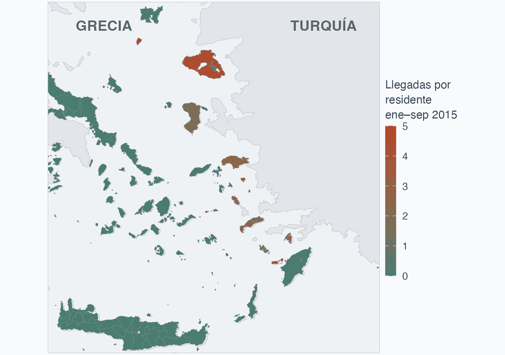

## Lo que necesitan saber

No lo han leído. Esto es lo que la tarea requiere:

- Los refugiados se quedaban **menos de 48 horas**, luego seguían al continente
- Así los autores descartan por diseño el **contacto** y la **competencia por recursos**
- La ruta que afirman: llegadas → **amenaza percibida** → voto por Amanecer Dorado
- El efecto: **+2 puntos**, un alza de 44% sobre una base de 4.5%

## La evidencia

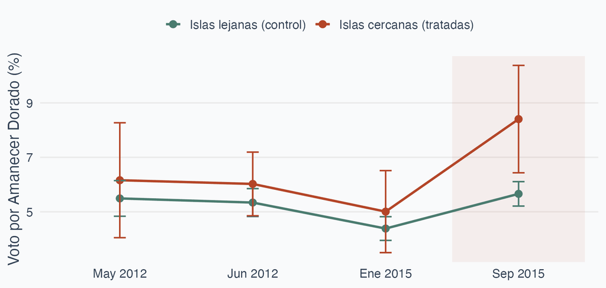

Tres elecciones a la par. Luego septiembre de 2015.

## Lo que concluyen

Tres frases del artículo (en el original):

> “mere exposure is sufficient to **fuel prejudice** and change political behavior” (p. 247)

> competition over “scarce resources **such as** access to jobs, housing, or education… there is no specific competition… over **any of these** resources” (p. 253)

> “the **ensuing chaos** on affected islands” (p. 253)

## Su tarea

**15 minutos, en parejas.** Una frase por punto — no están escribiendo un ensayo.

- **Movimiento 1** *(cita 1)* — “alimenta el prejuicio”: ¿descriptiva, causal, de mecanismo o general?
- **Movimiento 2** *(cita 2)* — escríbanlo como P1, P2, C. ¿Qué premisa nunca se dice?
- **Movimiento 3** *(la figura)* — ¿qué se contó, y se contó sobre personas o sobre municipios?
- **Movimiento 4** *(el mapa)* — ¿qué tiene que ser cierto de las islas cercanas y lejanas?
- **Movimiento 5** — nombren otra cosa que pudiera subir el voto 2 puntos.

Luego etiqueten cada una de sus tres afirmaciones: **sostenida** / **plausible** / **no establecida**.

## Respuestas rápidas

- **Movimiento 1** — **de mecanismo**. Dice *por qué* se movió el voto: por el prejuicio.
- **Movimiento 2** — no dicha: que empleo, vivienda y educación son los **únicos** recursos escasos.
- **Movimiento 3** — porcentajes de voto, contados sobre **municipios**. La afirmación es sobre la **cabeza** de la gente.
- **Movimiento 4** — ambos grupos debían venir en la **misma trayectoria** antes de 2015. La figura dice que sí.
- **Movimiento 5** — la disrupción, o la migración dominando las noticias. Las dos predicen los mismos 2 puntos.

Ahora tres de estas, a fondo.

## Revelación 1 — La premisa oculta

| P1. | El conflicto entre grupos requiere competencia por recursos escasos. |
| --- | --- |
| P2. | No hay competencia por empleo, vivienda ni educación. |
| P3. *(no dicha)* | Esos tres **son** los recursos escasos relevantes. |
| C. | Entonces el conflicto entre grupos no explica la reacción. |

“**such as**” abre la categoría. “**any of these**” la cierra. P3 nunca se defiende.

Policía, transporte, clínicas, espacio público — también escasos. La frase de los propios autores: *“ensuing chaos.”*

## Revelación 2 — Dos saltos

```
%%{init: {"flowchart": {"useMaxWidth": true, "htmlLabels": false, "nodeSpacing": 22, "rankSpacing": 46, "padding": 16}, "themeVariables": {"fontSize": "13px", "edgeLabelBackground": "#f9fafb"}}}%%
flowchart LR
  V["MEDIDO<br/>voto por municipio"] -.->|"de grupo a individuo"| I["votantes<br/>individuales"]
  I -.->|"de votos a mentes"| P["AFIRMADO<br/>prejuicio"]
  style V fill:#4a7c6f,color:#f9fafb,stroke:#4a7c6f
  style I fill:#f9fafb,color:#334155,stroke:#64748b
  style P fill:#b44527,color:#f9fafb,stroke:#b44527
```

El prejuicio nunca se mide. El resultado es un porcentaje de voto.

**Midieron votos, no prejuicio.**

## Revelación 3 — Rivales

```
%%{init: {"flowchart": {"useMaxWidth": true, "htmlLabels": false, "nodeSpacing": 18, "rankSpacing": 60, "padding": 16}, "themeVariables": {"fontSize": "13px", "edgeLabelBackground": "#f9fafb"}}}%%
flowchart LR
  A["A. Mera exposición<br/>ver refugiados"] --> R["Sube el voto de<br/>Amanecer Dorado"]
  B["B. Disrupción<br/>caos, servicios saturados"] --> R
  C["C. Saliencia<br/>la migración domina<br/>las noticias"] --> R
  style A fill:#b44527,color:#f9fafb,stroke:#b44527
  style B fill:#f9fafb,color:#334155,stroke:#64748b
  style C fill:#f9fafb,color:#334155,stroke:#64748b
  style R fill:#1e293b,color:#f9fafb,stroke:#1e293b
```

Las tres predicen el mismo resultado. La evidencia no discrimina.

## El veredicto calibrado

**Bien sostenido:** la llegada de refugiados subió el voto de Amanecer Dorado unos 2 puntos.

**Plausible, no establecido:** que lo haya hecho *ver refugiados*, y no la disrupción alrededor.

**No establecido con estos datos:** que el prejuicio de alguien haya cambiado.

Este es un **buen artículo**. Fíjate en que el veredicto sigue teniendo tres niveles.

# El machote

## Seis movimientos

1. **AFIRMACIÓN** — ¿qué exactamente me piden creer?
2. **ARGUMENTO** — ¿P1, P2, P3 oculta, C?
3. **MEDICIÓN** — ¿qué se midió, en qué nivel?
4. **COMPARACIÓN** — ¿comparado con qué, bajo qué supuesto?
5. **RIVALES** — ¿qué más predice esto? ¿discrimina?
6. **VEREDICTO** — sostenido / plausible / no establecido